# Passo a passo - Evasão Correntistas

Instalação e importação dos pacotes

```r
# install.packages("ggplot2")
# install.packages("data.table")
# install.packages("stargazer")
# install.packages("skimr")
# install.packages("Rcpp")
# install.packages("mlbench")
# install.packages("caretEnsemble")
# install.packages("rattle")
# install.packages("xray")
# install.packages("tidyverse")
# install.packages("tidyr")
# install.packages("psych")
library(ggplot2)
library(data.table)
library(stargazer)
library(skimr)
library(Rcpp)
library(readxl)
library(dplyr)
library(tidyverse)
library(caret)
library(mlbench)
library(caretEnsemble)
library(rattle)
```

Criação da função que gera os gráficos.

```r
### FUNÇÃO
box_plot = function(data, atributos, atributosSubgrupo, variavelDependente = 'Evadiu_formatado'){
  for (atributo in atributos) {
    if(length(atributosSubgrupo) > 0){
      for (atributo2 in atributosSubgrupo){
      result = ggplot(data = dtAmostra, aes_string(variavelDependente, atributo)) +
        geom_boxplot(aes_string(fill = atributo2)) +
        # geom_boxplot() +
        labs(x = variavelDependente,
             y = atributo,
             title = "Boxplot",
             subtitle = paste(atributo, variavelDependente, sep = " vs "),
             caption = "") +
        theme_bw()
        # facet_wrap(~ atributo2)
      print(result)
     }
    }
    else{
      result = ggplot(data = dtAmostra, aes_string(variavelDependente, atributo)) +
        geom_boxplot() +
        labs(x = variavelDependente,
             y = atributo,
             title = "Boxplot",
             subtitle = paste(atributo, variavelDependente, sep = " vs "),
             caption = "") +
        theme_bw()
        # facet_wrap(~ atributo2)
      print(result)
    }
  }
}
```

Leitura do arquivo feita e análise dos dados

```r
dtAmostra <- fread("dadosBanco/Amostra_Modelo_Evasao_Correntistas_v3.csv")
str(dtAmostra)
```

```
Classes ‘data.table’ and 'data.frame':  100000 obs. of  36 variables:
 $ Id                            : int  1 2 3 4 5 6 7 8 9 10 ...
 $ Evadiu                        : int  0 1 1 0 1 0 0 0 1 1 ...
 $ Segmento                      : chr  "GR" "GC" "GC" "GV" ...
 $ Debito_Automatico             : int  0 0 0 0 0 1 1 0 0 0 ...
 $ Credito_Salario               : int  1 1 0 0 0 0 1 0 1 0 ...
 $ Credenciamento                : int  0 0 0 0 0 0 0 0 0 0 ...
 $ Caixa_Seguradora              : int  1 0 0 0 0 1 1 1 0 0 ...
 $ Pediu_Portabilidade           : int  0 0 0 0 0 0 0 0 0 0 ...
 $ Abriu_Reclamacao              : int  0 0 0 0 0 0 0 0 0 0 ...
 $ Debito_Automatico_DIF         : int  0 0 0 0 0 0 0 0 0 0 ...
 $ Credito_Salario_DIF           : int  1 1 0 0 0 0 0 0 0 0 ...
 $ Caixa_Seguradora_DIF          : int  0 0 0 0 0 0 0 0 0 0 ...
 $ Produtos_Qualificados         : int  6 0 5 4 5 6 11 8 3 3 ...
 $ Produtos_Qualificados_Anterior: int  8 1 6 3 5 5 8 10 3 3 ...
```

[output cut: 23 more lines]

Como é possível verificar, existem uma série de dados que são caracterizados como inteiro, porém na verdade são variáveis que servem para *classificar* um determinado cliente.

Dessa forma, as variáveis foram transformadas em *fatores*.

```r
dtAmostra$Evadiu <- as.factor(dtAmostra$Evadiu)
dtAmostra$Debito_Automatico <- as.factor(dtAmostra$Debito_Automatico)
dtAmostra$Credito_Salario <- as.factor(dtAmostra$Credito_Salario)
dtAmostra$Credenciamento <- as.factor(dtAmostra$Credenciamento)
dtAmostra$Caixa_Seguradora <- as.factor(dtAmostra$Caixa_Seguradora)
dtAmostra$Pediu_Portabilidade <- as.factor(dtAmostra$Pediu_Portabilidade)
dtAmostra$Abriu_Reclamacao <- as.factor(dtAmostra$Abriu_Reclamacao)
dtAmostra$Debito_Automatico_DIF <- as.factor(dtAmostra$Debito_Automatico_DIF)
dtAmostra$Credito_Salario_DIF <- as.factor(dtAmostra$Credito_Salario_DIF)
dtAmostra$Caixa_Seguradora_DIF <- as.factor(dtAmostra$Caixa_Seguradora_DIF)
dtAmostra =
  dtAmostra %>%
  mutate(Evadiu = ifelse(Evadiu == 1, "Sim", "Não")) %>%
  mutate(Segmento = ifelse(Segmento == "GV", "Renda_Basica", ifelse(Segmento == "GC", "Classe_Media", ifelse(Segmento == "GR", "Alta_Renda", "Exclusivo"))))
str(dtAmostra)
```

```
'data.frame':   100000 obs. of  36 variables:
 $ Id                            : int  1 2 3 4 5 6 7 8 9 10 ...
 $ Evadiu                        : chr  "Não" "Sim" "Sim" "Não" ...
 $ Segmento                      : chr  "Alta_Renda" "Classe_Media" "Classe_Media" "Renda_Basica" ...
 $ Debito_Automatico             : Factor w/ 2 levels "0","1": 1 1 1 1 1 2 2 1 1 1 ...
 $ Credito_Salario               : Factor w/ 2 levels "0","1": 2 2 1 1 1 1 2 1 2 1 ...
 $ Credenciamento                : Factor w/ 2 levels "0","1": 1 1 1 1 1 1 1 1 1 1 ...
 $ Caixa_Seguradora              : Factor w/ 2 levels "0","1": 2 1 1 1 1 2 2 2 1 1 ...
 $ Pediu_Portabilidade           : Factor w/ 1 level "0": 1 1 1 1 1 1 1 1 1 1 ...
 $ Abriu_Reclamacao              : Factor w/ 1 level "0": 1 1 1 1 1 1 1 1 1 1 ...
 $ Debito_Automatico_DIF         : Factor w/ 3 levels "-1","0","1": 2 2 2 2 2 2 2 2 2 2 ...
 $ Credito_Salario_DIF           : Factor w/ 3 levels "-1","0","1": 3 3 2 2 2 2 2 2 2 2 ...
 $ Caixa_Seguradora_DIF          : Factor w/ 3 levels "-1","0","1": 2 2 2 2 2 2 2 2 2 2 ...
 $ Produtos_Qualificados         : int  6 0 5 4 5 6 11 8 3 3 ...
 $ Produtos_Qualificados_Anterior: int  8 1 6 3 5 5 8 10 3 3 ...
```

[output cut: 22 more lines]

A variável **Pediu_Portabilidade** possui um valor constante e, por conta disso, foi retirada.

Como o interesse é buscar predizer a variável **Evadiu**, verificamos todas as outras variáveis em conjunto com a variável alvo para verificar o resultado.

No entanto, nos deparamos com algo do tipo:

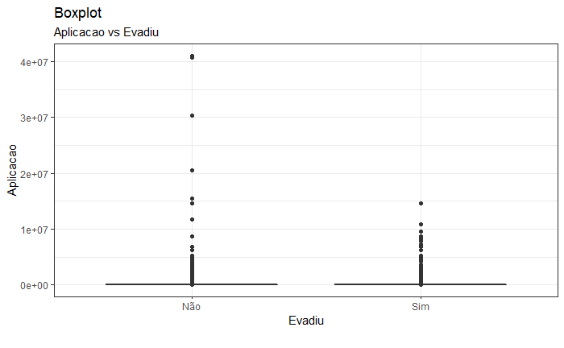

Ou seja, existem outliers com valores muito altos e que, na verdade, não estão dentro da maioria dos dados relevantes (75%).

Assim, aplicamos uma função chamada *winsor* que tem a função de eliminar esses outliers, como foi feito abaixo:

```r
dtAmostra = dtAmostra %>%
  mutate(winsored_Rentabilidade_PERC = psych::winsor(Rentabilidade_PERC, 0.1)) %>%
  mutate(winsored_Produtos = psych::winsor(Produtos, 0.01)) %>%
  mutate(winsored_Produtos_Qualificados_PERC = psych::winsor(Produtos_Qualificados_PERC, 0.01)) %>%
  mutate(winsored_Produtos_PERC = psych::winsor(Produtos_PERC, 0.01)) %>%
  mutate(winsored_Movimentacoes = psych::winsor(Movimentacoes, 0.1)) %>%
  mutate(winsored_Movimentacoes_Anterior = psych::winsor(Movimentacoes_Anterior, 0.1)) %>%
  mutate(winsored_Movimentacoes_DIF = psych::winsor(Movimentacoes_DIF, 0.1)) %>%
  mutate(winsored_Movimentacoes_PERC = psych::winsor(Movimentacoes_PERC, 0.1)) %>%
  mutate(winsored_Aplicacao = psych::winsor(Aplicacao, 0.1)) %>%
  mutate(winsored_Aplicacao_Anterior = psych::winsor(Aplicacao_Anterior, 0.1)) %>%
  mutate(winsored_Aplicacao_DIF = psych::winsor(Aplicacao_DIF, 0.1)) %>%
  mutate(winsored_Aplicacao_PERC = psych::winsor(Aplicacao_PERC, 0.1)) %>%
  mutate(winsored_Credito = psych::winsor(Credito, 0.1)) %>%
  mutate(winsored_Credito_Anterior = psych::winsor(Credito_Anterior, 0.1)) %>%
  mutate(winsored_Credito_DIF = psych::winsor(Credito_DIF, 0.1)) %>%
  mutate(winsored_Credito_PERC = psych::winsor(Credito_PERC, 0.1)) %>%
  mutate(winsored_Rentabilidade = psych::winsor(Rentabilidade, 0.1)) %>%
  mutate(winsored_Rentabilidade_Anterior = psych::winsor(Rentabilidade_Anterior, 0.1)) %>%
  mutate(winsored_Rentabilidade_DIF = psych::winsor(Rentabilidade_DIF, 0.1)) %>%
  mutate(winsored_Rentabilidade_PERC = psych::winsor(Rentabilidade_PERC, 0.1))
```

Feito isso, rodamos novamente os gráficos para verificarmos quais das variáveis mais seria interessante de se usar como preditora da variável alvo.

Segue resultado abaixo:

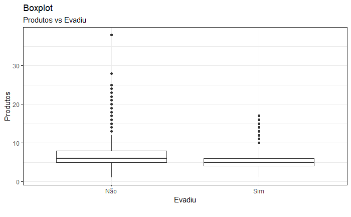

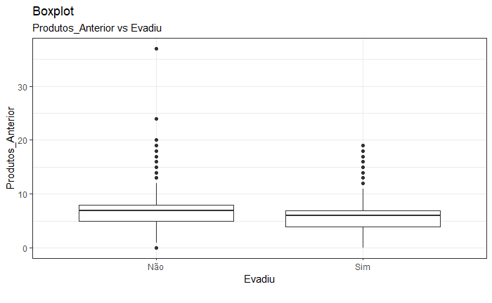

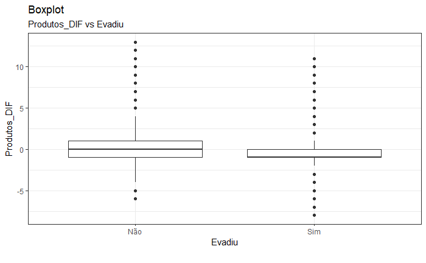

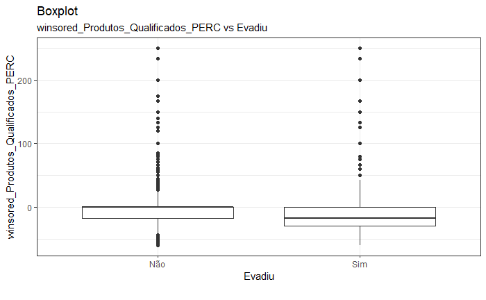

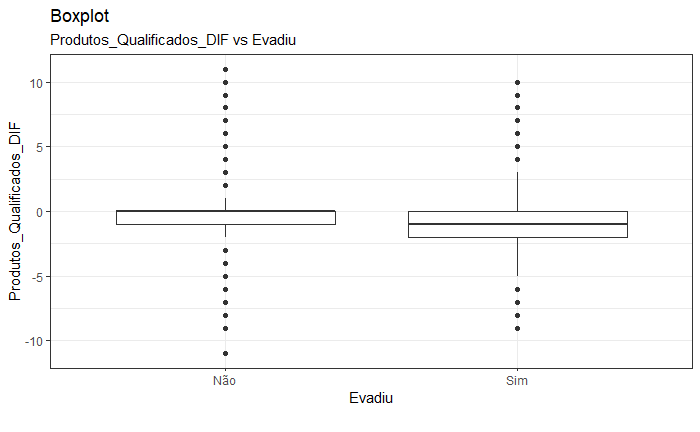

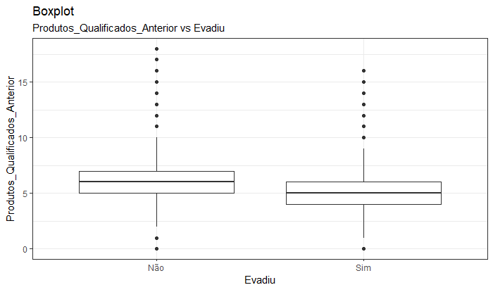

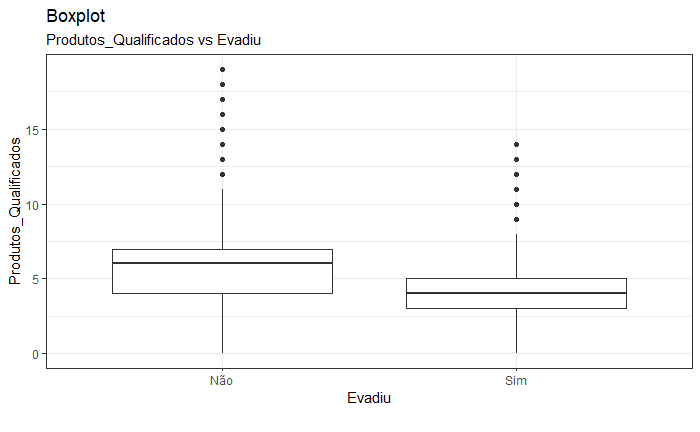

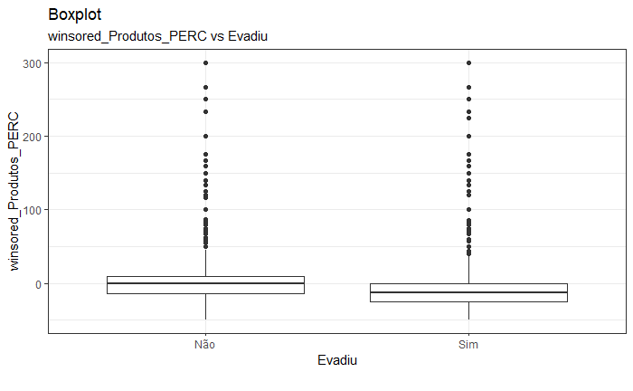

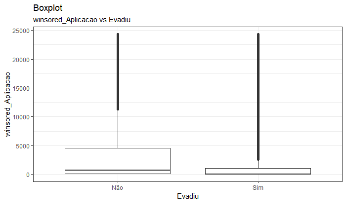

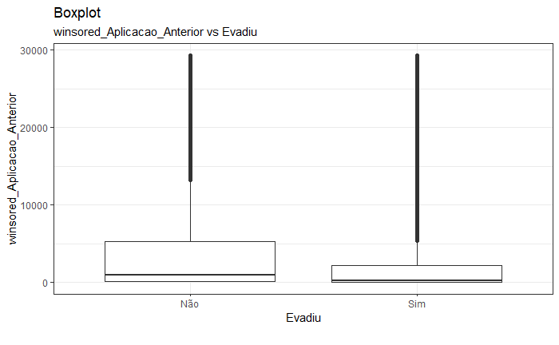

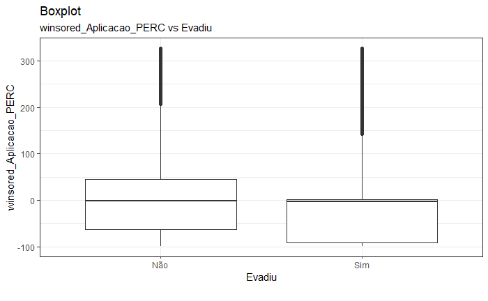

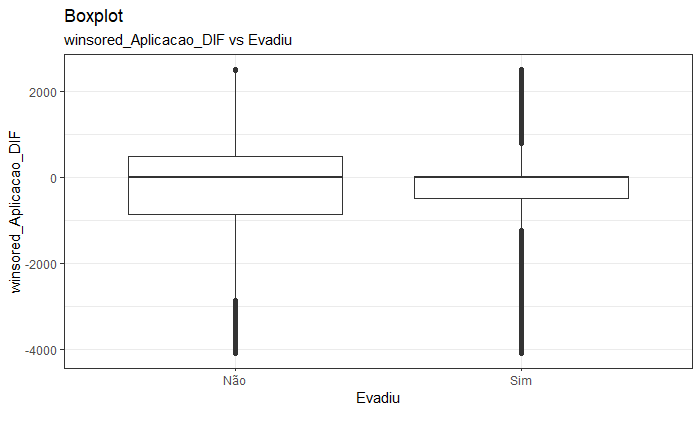

[12 more figures not shown]

É interessante colocar também que aquelas variáveis que foram identificadas como fatores não tiveram um bom relacionamento a preditora, assim foram utilizadas como uma *terceira variável de análise (visão)* em conjunto com aquelas variáveis que tiveram um melhor resultado na predição:

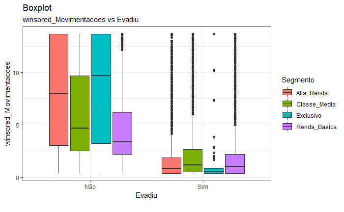

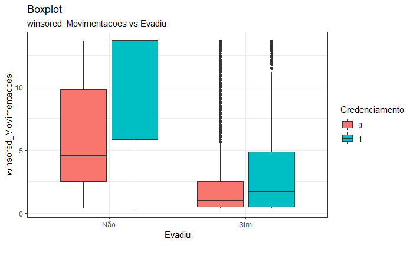

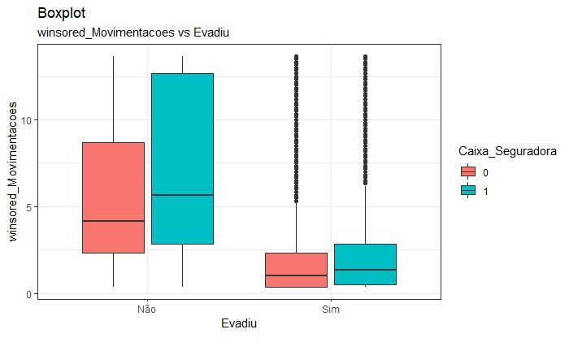

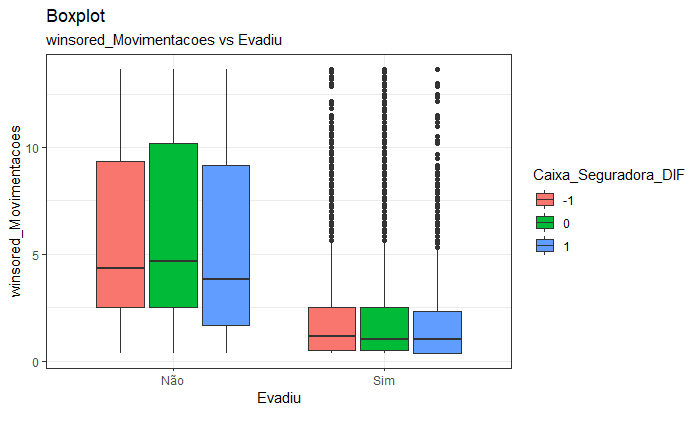

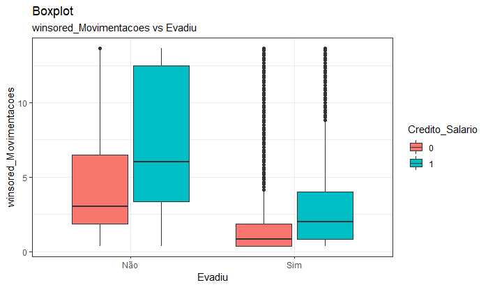

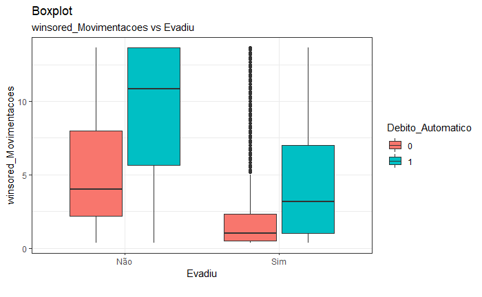

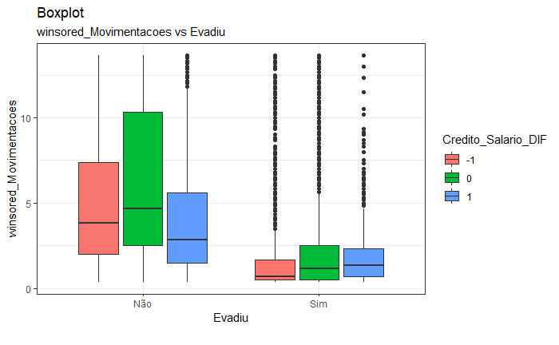

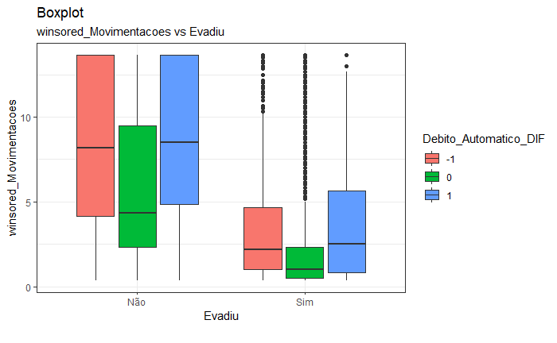

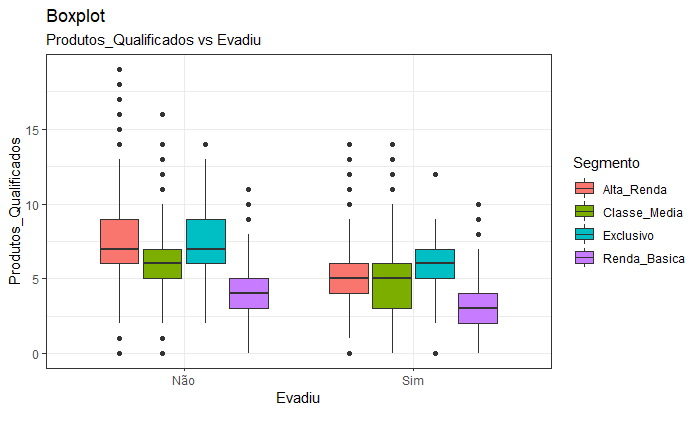

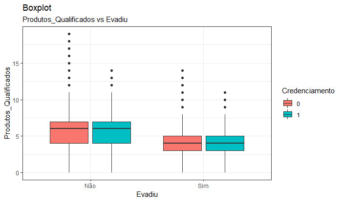

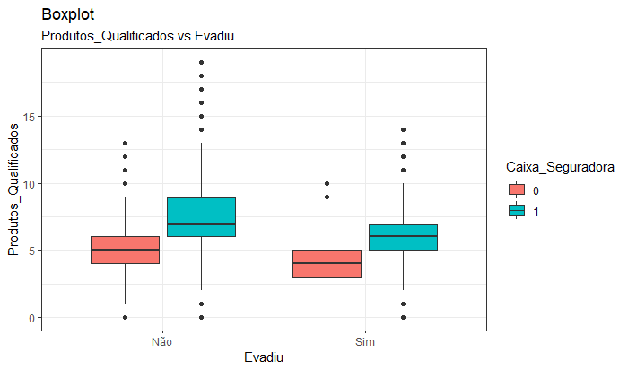

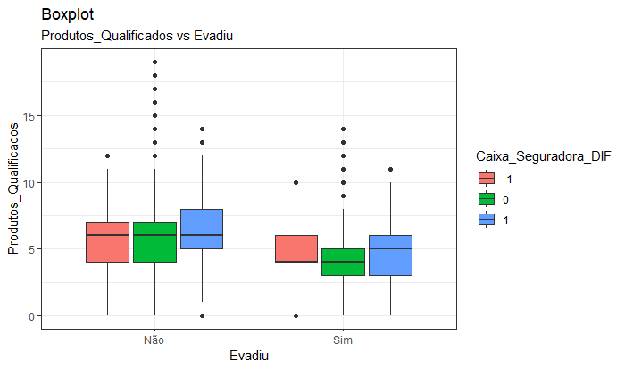

[20 more figures not shown]

Agora começamos o trabalho de execução da rotina de regressão.

Criação das dummy variables.

```r
str(dtAmostra)
```

[output not shown]

[output cut: 43 more lines]

```r
dtAmostra =
  dtAmostra %>%
  mutate_if(is.ordered, as.numeric) %>%
  mutate(EvadiuTipo = as.numeric(Evadiu)) %>%
  mutate(Segmento_Num1 = ifelse(Segmento == "GV", 1, ifelse(Segmento == "GC", 2, ifelse(Segmento == "GR", 3, 4)))) %>%
  mutate(Segmento_Num = as.factor(Segmento_Num1)) %>%
  select(-Id, -Evadiu, -Evadiu_formatado, -Segmento_Descricao, -Segmento, -Segmento_Num1, -Pediu_Portabilidade, -Abriu_Reclamacao) %>%
  drop_na() %>%
  as.data.table()
dummyVar_model = dummyVars(formula = ~ .,
                           data = dtAmostra)
data = as.data.table(predict(dummyVar_model, newdata = dtAmostra))
str(data)
```

```
Classes ‘data.table’ and 'data.frame':  100000 obs. of  65 variables:
 $ Debito_Automatico.0                : num  1 1 1 1 1 0 0 1 1 1 ...
 $ Debito_Automatico.1                : num  0 0 0 0 0 1 1 0 0 0 ...
 $ Credito_Salario.0                  : num  0 0 1 1 1 1 0 1 0 1 ...
 $ Credito_Salario.1                  : num  1 1 0 0 0 0 1 0 1 0 ...
 $ Credenciamento.0                   : num  1 1 1 1 1 1 1 1 1 1 ...
 $ Credenciamento.1                   : num  0 0 0 0 0 0 0 0 0 0 ...
 $ Caixa_Seguradora.0                 : num  0 1 1 1 1 0 0 0 1 1 ...
 $ Caixa_Seguradora.1                 : num  1 0 0 0 0 1 1 1 0 0 ...
 $ Debito_Automatico_DIF.-1           : num  0 0 0 0 0 0 0 0 0 0 ...
 $ Debito_Automatico_DIF.0            : num  1 1 1 1 1 1 1 1 1 1 ...
 $ Debito_Automatico_DIF.1            : num  0 0 0 0 0 0 0 0 0 0 ...
 $ Credito_Salario_DIF.-1             : num  0 0 0 0 0 0 0 0 0 0 ...
 $ Credito_Salario_DIF.0              : num  0 0 1 1 1 1 1 1 1 1 ...
 $ Credito_Salario_DIF.1              : num  1 1 0 0 0 0 0 0 0 0 ...
```

[output cut: 52 more lines]

```r
problematicVariables = nearZeroVar(data, names = T)
problematicVariables
```

```
[1] "Credenciamento.0"         "Credenciamento.1"         "Debito_Automatico_DIF.-1" "Debito_Automatico_DIF.1"  "Credito_Salario_DIF.-1"
[6] "Credito_Salario_DIF.1"    "Caixa_Seguradora_DIF.-1"  "Caixa_Seguradora_DIF.1"   "Segmento_Num.4"
```

```r
data =
  data %>%
  select(-problematicVariables) %>%
  mutate(EvadiuTipo = case_when(
                            EvadiuTipo == 2 ~ "Não",
                            EvadiuTipo == 1 ~ "Sim"))
str(data)
```

```
'data.frame':   100000 obs. of  56 variables:
 $ Debito_Automatico.0                : num  1 1 1 1 1 0 0 1 1 1 ...
 $ Debito_Automatico.1                : num  0 0 0 0 0 1 1 0 0 0 ...
 $ Credito_Salario.0                  : num  0 0 1 1 1 1 0 1 0 1 ...
 $ Credito_Salario.1                  : num  1 1 0 0 0 0 1 0 1 0 ...
 $ Caixa_Seguradora.0                 : num  0 1 1 1 1 0 0 0 1 1 ...
 $ Caixa_Seguradora.1                 : num  1 0 0 0 0 1 1 1 0 0 ...
 $ Debito_Automatico_DIF.0            : num  1 1 1 1 1 1 1 1 1 1 ...
 $ Credito_Salario_DIF.0              : num  0 0 1 1 1 1 1 1 1 1 ...
 $ Caixa_Seguradora_DIF.0             : num  1 1 1 1 1 1 1 1 1 1 ...
 $ Produtos_Qualificados              : num  6 0 5 4 5 6 11 8 3 3 ...
 $ Produtos_Qualificados_Anterior     : num  8 1 6 3 5 5 8 10 3 3 ...
 $ Produtos_Qualificados_DIF          : num  -2 -1 -1 1 0 1 3 -2 0 0 ...
 $ Produtos_Qualificados_PERC         : num  -25 -100 -16.7 33.3 0 ...
 $ Produtos                           : num  6 6 5 4 6 8 14 9 5 3 ...
```

[output cut: 42 more lines]

Criação as estatísticas

```r
stargazer::stargazer(data, type = "text")
```

```
==============================================================================================================================
Statistic                              N       Mean        St. Dev.          Min        Pctl(25)  Pctl(75)         Max
------------------------------------------------------------------------------------------------------------------------------
Debito_Automatico.0                 100,000    0.898        0.303             0            1         1              1
Debito_Automatico.1                 100,000    0.102        0.303             0            0         0              1
Credito_Salario.0                   100,000    0.562        0.496             0            0         1              1
Credito_Salario.1                   100,000    0.438        0.496             0            0         1              1
Caixa_Seguradora.0                  100,000    0.713        0.452             0            0         1              1
Caixa_Seguradora.1                  100,000    0.287        0.452             0            0         1              1
Debito_Automatico_DIF.0             100,000    0.937        0.243             0            1         1              1
Credito_Salario_DIF.0               100,000    0.927        0.260             0            1         1              1
Caixa_Seguradora_DIF.0              100,000    0.912        0.284             0            1         1              1
Produtos_Qualificados               100,000    5.036        2.155             0            4         6              19
Produtos_Qualificados_Anterior      100,000    5.491        2.340             0            4         7              18
Produtos_Qualificados_DIF           100,000   -0.455        1.557            -11           -1        0              11
Produtos_Qualificados_PERC          100,000   -3.710        55.412           -100         -25        0            1,100
Produtos                            100,000    5.934        2.376             1            4         7              38
Produtos_Anterior                   100,000    6.146        2.526             0            5         8              37
Produtos_DIF                        100,000   -0.212        1.724             -8           -1        0              13
Produtos_PERC                       100,000    2.897        64.076         -87.500      -20.000    0.000        1,100.000
Movimentacoes                       100,000    5.555        9.445           0.167        1.000     5.833         297.333
Movimentacoes_Anterior              100,000    5.752        9.410             0            1        6.2            384
Movimentacoes_DIF                   100,000   -0.197        5.307          -131.167      -1.000    1.000         121.167
Movimentacoes_PERC                  100,000   24.779       250.392         -99.663      -33.333    23.529       22,300.000
Aplicacao                           100,000 23,493.230   281,009.400        0.000        10.160  2,696.358    41,043,558.000
Aplicacao_Anterior                  100,000 26,087.180   307,230.000        0.000        28.090  3,754.172    47,580,215.000
Aplicacao_DIF                       100,000 -2,593.947   105,691.200   -16,559,375.000  -652.970  176.930     3,947,592.000
Aplicacao_PERC                      100,000 196,581.300 57,988,836.000     -100.000     -76.649    18.142   18,334,162,900.000
Credito                             100,000 27,441.200    64,423.870          0            0      25,443.4      3,153,455
Credito_Anterior                    100,000 27,479.220    65,758.530        0.000        0.000   24,353.350   2,962,917.000
Credito_DIF                         100,000   -38.019     24,838.690    -2,938,766.000  -965.355   21.133     1,547,627.000
Credito_PERC                        100,000  3,557.453   238,781.400         -100         -4.2       0          39,470,897
Rentabilidade                       100,000  2,445.000    35,272.240     -24,504.080    215.450  2,338.830    10,946,673.000
Rentabilidade_Anterior              100,000  2,197.051    17,883.800      -2,023.930    151.980  2,171.447    5,338,958.000
Rentabilidade_DIF                   100,000   247.949     17,972.220     -93,281.750    -32.850   266.973     5,607,715.000
Rentabilidade_PERC                  100,000  4,490.862   757,750.700   -200,046,700.000 -10.819    34.325     66,256,633.000
winsored_Rentabilidade_PERC         100,000   19.381        46.984         -38.380      -10.819    34.325        123.926
winsored_Produtos                   100,000    5.920        2.323             1            4         7              13
winsored_Produtos_Qualificados_PERC 100,000   -5.401        39.684           -60          -25        0             250
```

[output cut: 20 more lines]

```r
skimr::skim_to_wide(data)
```

| type | variable | missing | complete | n | min | max | empty | n_unique | mean | sd | p0 | p25 | p50 | p75 | p100 | hist |
| --- | --- | --- | --- | --- | --- | --- | --- | --- | --- | --- | --- | --- | --- | --- | --- | --- |
| character | EvadiuTipo | 0 | 100000 | 100000 | 3 | 3 | 0 | 2 | NA | NA | NA | NA | NA | NA | NA | NA |
| numeric | Aplicacao | 0 | 100000 | 100000 | NA | NA | NA | NA | 23493.23 | 281009.37 | 0 | 10.16 | 273.12 | 2696.36 | 4.1e+07 |  |
| numeric | Aplicacao_Anterior | 0 | 100000 | 100000 | NA | NA | NA | NA | 26087.18 | 307230.02 | 0 | 28.09 | 484.25 | 3754.17 | 4.8e+07 |  |
| numeric | Aplicacao_DIF | 0 | 100000 | 100000 | NA | NA | NA | NA | -2593.95 | 105691.19 | -1.7e+07 | -652.97 | -1.12 | 176.93 | 3947591.64 |  |
| numeric | Aplicacao_PERC | 0 | 100000 | 100000 | NA | NA | NA | NA | 2e+05 | 5.8e+07 | -100 | -76.65 | -1.73 | 18.14 | 1.8e+10 |  |
| numeric | Caixa_Seguradora.0 | 0 | 100000 | 100000 | NA | NA | NA | NA | 0.71 | 0.45 | 0 | 0 | 1 | 1 | 1 |  |
| numeric | Caixa_Seguradora.1 | 0 | 100000 | 100000 | NA | NA | NA | NA | 0.29 | 0.45 | 0 | 0 | 0 | 1 | 1 |  |
| numeric | Caixa_Seguradora_DIF.0 | 0 | 100000 | 100000 | NA | NA | NA | NA | 0.91 | 0.28 | 0 | 1 | 1 | 1 | 1 |  |
| numeric | Credito | 0 | 100000 | 100000 | NA | NA | NA | NA | 27441.2 | 64423.87 | 0 | 0 | 1160.33 | 25443.4 | 3153454.55 |  |
| numeric | Credito_Anterior | 0 | 100000 | 100000 | NA | NA | NA | NA | 27479.22 | 65758.53 | 0 | 0 | 1071.06 | 24353.35 | 3e+06 |  |

[output cut: 46 more lines]

```r
xray::anomalies(data)
```

```
Found 2 possible problematic variables:
Debito_Automatico.1, Segmento_Num.3
```

| Variable | q | qNA | pNA | qZero | pZero | qBlank | pBlank | qInf | pInf | qDistinct | type | anomalous_percent |
| --- | --- | --- | --- | --- | --- | --- | --- | --- | --- | --- | --- | --- |
| Debito_Automatico.1 | 100000 | 0 | - | 89756 | 89.76% | 0 | - | 0 | - | 2 | Numeric | 89.76% |
| Segmento_Num.3 | 100000 | 0 | - | 86716 | 86.72% | 0 | - | 0 | - | 2 | Numeric | 86.72% |
| Segmento_Num.1 | 100000 | 0 | - | 77438 | 77.44% | 0 | - | 0 | - | 2 | Numeric | 77.44% |
| Caixa_Seguradora.1 | 100000 | 0 | - | 71324 | 71.32% | 0 | - | 0 | - | 2 | Numeric | 71.32% |
| Credito_Salario.1 | 100000 | 0 | - | 56188 | 56.19% | 0 | - | 0 | - | 2 | Numeric | 56.19% |
| Credito_Salario.0 | 100000 | 0 | - | 43812 | 43.81% | 0 | - | 0 | - | 2 | Numeric | 43.81% |
| winsored_Credito_PERC | 100000 | 0 | - | 37334 | 37.33% | 0 | - | 0 | - | 38584 | Numeric | 37.33% |
| Credito_PERC | 100000 | 0 | - | 37334 | 37.33% | 0 | - | 0 | - | 53556 | Numeric | 37.33% |
| winsored_Credito_Anterior | 100000 | 0 | - | 37175 | 37.18% | 0 | - | 0 | - | 49980 | Numeric | 37.18% |
| Credito_Anterior | 100000 | 0 | - | 37175 | 37.18% | 0 | - | 0 | - | 59974 | Numeric | 37.18% |

[output cut: 46 more lines]

| Variable | q | qNA | pNA | qZero | pZero | qBlank | pBlank | qInf | pInf | qDistinct | type | anomalous_percent | problems |
| --- | --- | --- | --- | --- | --- | --- | --- | --- | --- | --- | --- | --- | --- |
| Debito_Automatico.1 | 100000 | 0 | - | 89756 | 89.76% | 0 | - | 0 | - | 2 | Numeric | 89.76% | Anomalies present in 89.76% of the rows. |
| Segmento_Num.3 | 100000 | 0 | - | 86716 | 86.72% | 0 | - | 0 | - | 2 | Numeric | 86.72% | Anomalies present in 86.72% of the rows. |

```
NA
```

Criando os modelos de treinamento da regressão

```r
control <- trainControl(method = "repeatedcv", #boot, cv, LOOCV, timeslice OR adaptive etc.
                        number = 10,
                        repeats = 20,
                        classProbs = TRUE,
                        summaryFunction = twoClassSummary,
                        savePredictions = "final",
                        allowParallel = TRUE)
```

Rodando árvore de decisão com repeated k-fold cross-validation

[figure not shown]

```r
models =
      caretList(EvadiuTipo ~ .,
                data = dtAmostra,
                trControl = control,
                metric = "ROC",
                tuneList = list(#adaboost     = caretModelSpec(method = "adaboost"), #muito demorado para rodar
                                arvoreDecisao = caretModelSpec(method = "rpart",
                                                               tuneGrid = expand.grid(cp = seq(0, 10, length = 20))),
                                knn           = caretModelSpec(method = "knn"),
                                logit         = caretModelSpec(method = "glm", family = "binomial"),
                                elasticnet    = caretModelSpec(method = "glmnet"),
                                redeNeural    = caretModelSpec(method = "mlpML"),
                                rf            = caretModelSpec(method = "ranger")),
                preProcess = c("knnImpute", "nzv", "center", "scale"))
```

[output not shown]